# Chapter 2 Exercises

Aidan O’Keeffe

2023-03-06

# Conceptual

## Exercise 1

#### Problem

For each of parts (a) through (d), indicate whether we would generally expect the performance of a flexible statistical learning method to be better or worse than an inflexible model. Justify your answer.

1. The sample size $n$ is extremely large, and the number of predictors $p$ is small.
2. The number of predictors $p$ is extremely large, and the number of observations $n$ is small.
3. The relationship between the predictors and response is highly nonlinear.
4. The variance of the error terms, i.e. $\sigma^2 = \mbox{Var}(\epsilon)$, is extremely high.

### Solution

1. A flexible model would likely perform much better than an inflexible model for two reasons. First, the relationship between the predictors and the response becomes more and more clear as the sample size grows, and since such relationships are almost always nonlinear, a flexible method could capitalize on the abundance of data to find such relationships. Second, because the number of predictors is small, we are in a low dimensional setting, meaning that we do not suffer from the curse of dimensionality, hence we could even expect extremely flexible nonparametric models to show good performance.
2. In this case, we would expect better performance from a less flexible model. Given a small $n$, as $p$ increases, overfitting becomes inevitable, which would lead to a high test error rate. A less flexible model could identify a broad trend from what data *is* available while not fitting the sample too closely.
3. If the relationship between the predictors and the response is highly nonlinear, then a flexible method will perform better because it will provide a smaller model bias than a less flexible method.
4. The problem with high-variance errors is that they obscure the true response-predictor relationship. In this case, a flexible method will be fit to the errors, almost certainly leading to poor test performance. As with scenario (b), we’d be better off using a less flexible model and identifying a broad trend in the data, thereby not fitting the noise too closely.

## Exercise 2

### Problem

Explain whether each scenario is a classification or regression problem, and indicate whether we are more interested in inference or prediction. Finally, provide $n$ and $p$.

1. We collect a set of data on the top 500 firms in the US. For each firm, we record profit, number of employees, industry, and the CEO salary. We are interested in understanding which factors affect CEO salary.
2. We are considering launching a new product and wish to know whether it will be a *success* or *failure*. We collect data on 20 similar products that were previously launched. For each product, we have recorded whether it was a success or failure, price charged for the product, marketing budget, competition price, and ten other variables.
3. We are interested in predicting the % change in the USD/Euro exchange rate in relation to the weekly changes in the world stock markets. Hence, we collect weekly data for all of 2012. For each week, we record the % change in the USD/Euro, the % change in the US market, the % change in the British market, and the % change in the German market.

### Solution

1. This is a regression problem because CEO salary is a continuous quantity, and the interest is in inference, as indicated by the phrase “we are interested in understanding”. $n$ = 500, $p$ = 3.
2. This is a classification problem because the response is a discrete quantity, *success* or *failure*. The interest here is in prediction because we want to know what the outcome will be for this particular “new product” we’re launching. $n$ = 20, $p$ = 13.
3. This is a regression problem because % change is a continuous quantity. The problem tells us outright that it’s one of prediction. $n$ = 52 (the number of weeks in a year), and $p$ = 3.

## Exercise 3

### Problem

We now revisit the bias-variance decomposition.

1. Provide a sketch of typical (squared) bias, variance, training error, test error, and Bayes (or irreducible) error curves, on a single plot, as we go from less flexible statistical learning methods towards more flexible approaches. The x-axis should represent the amount of flexibility in the method, and the y-axis should represent the values for each curve. There should be five curves. Make sure to label each one.
2. Explain why each of the five curves has the shape displayed in part (a).

### Solution

1. The code block below graphs the five curves in question. Note that the specific parameter values and functional forms don’t matter, they were chosen simply because they produce the correct general shape.

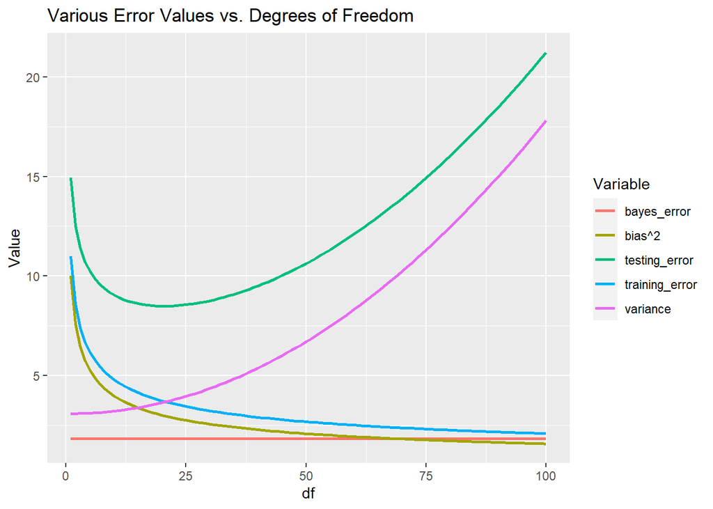

```r
library(tidyverse)

# Generate the curves to be plotted
df = 1:100
bias2 = 10/(df^0.4)
variance = 0.006*((df-1)/2)^2 + 3.1
train = 11/(df^0.36)
bayes = rep(1.84, 100)
test = bias2 + variance + bayes

data = data.frame( rep(1:100, 5),
                   rep(c("bias^2", "variance", "training_error", "testing_error", "bayes_error"),
                       each=100)  )
data = data.frame(data, c(bias2,variance,train,test,bayes  ))
names(data) = c("df", "Variable", "Value")

# Plot them
plt <- ggplot(data=data, aes(x=df, y=Value, group=Variable))+
  geom_line(aes(color=Variable), linewidth=1)+
  labs(x="df", y="Value")+
  ggtitle("Various Error Values vs. Degrees of Freedom")

plt
```

2. The Bayes error is a constant because it is defined as the variance of the error terms, that is, $\mbox{Var}(\epsilon)$, a quantity which does not vary with the degrees of freedom. The squared bias is represented as a decreasing function that converges to 0, which is the case because as a model becomes more flexible, its form is less constrained, and so the error due to model bias approaches 0. The testing error (in an ideal setting) is represented as the sum of the squared bias, the variance, and the Bayes error, which is justified by the bias-variance decomposition. The training error is represented as another decreasing function that converges to 0, which is the case because as model flexibility increases, it becomes possible to overfit, even to the extreme case of interpolating the data points. Finally, the variance is an increasing function of flexibility. The text doesn’t give a detailed argument as to why this is the case, but nonetheless says it is so.

## Exercise 4

### Problem

You will now think of some real life applications for statistical learning.

1. Describe three real-life applications in which *classification* might be useful. Describe the response, as well as the predictors. Is the goal of each application inference or prediction? Explain your answer.
2. Describe three real-life applications in which *regression* might be useful. Describe the response, as well as the predictors. Is the goal of each application inference or prediction? Explain your answer.
3. Describe three real-life applications in which *cluster analysis* might be useful.

### Solution

1. 1. We may want to understand (infer) if a student will pass or fail a class on the basis of their sex, age, GPA, and major.
   2. We may want to predict if a political candidate will win or lose an election on the basis of their sex, age, political party, state, fundraising, and if they are the incumbent or not.
   3. We may want to predict if a car will sell or not on the basis of make, model, year, and mileage.
2. 1. We may want to relate (infer) the mean delivery time of packets on a computer network on the basis of the number of nodes, traffic over time, and an assortment of measures of network structure.
   2. We may want to predict the change in sales on the basis of radio, TV, and newspaper advertising budgets and location data.
   3. We may want to predict body fat as a function of neck, waist, and hip measurements, weight, height, and biological sex.
3. 1. We want to identify online shoppers who are likely to buy a certain product by finding those who have bought many items with the same tags/product descriptors as the one in question.
   2. We want to advertise a fuel rewards program by identifying drivers who drive many miles, use a diesel or gas engine, and what kind of vehicle they drive.
   3. We want to identify residents of a neighborhood who are using many resources, such as water, electricity, and gas.

## Exercise 5

### Problem

What are the advantages and disadvantages of a very flexible (versus less flexible) approach for regression or classification? Under what circumstances might a more flexible approach be preferred to a less flexible approach? When might a less flexible approach be preferred?

### Solution

Focusing on regression, flexible methods are capable of producing more accurate predictions than less flexible methods. They perform well when we have a large sample size, when the variance of the error terms is small, and when the number of predictors is much smaller than the sample size. If any of these assumptions are violated, then a less flexible method will likely exhibit better performance.

## Exercise 6

### Problem

Describe the differences between a parametric and non-parametric statistical learning approach. What are the advantages of a parametric approach to regression of classification (as opposed to a non-parametric approach)? What are its disadvantages?

### Solution

Parametric models assume a functional form of the relationship between the response and the predictors, whereas non-parametric functions don’t. Parametric approaches are easier to interpret than non-parametric approaches, they are less computationally intensive to fit, and they perform better in high dimensional settings, although they may give less accurate predictions than non-parametric methods due to having higher model bias.

## Exercise 7

### Problem

The table below provides a training data set containing six observations, three predictors, and one qualitative response variable.

```r
data = data.frame(c(0,2,0,0,-1,1),c(3,0,1,1,0,1),c(0,0,3,2,1,1),
                  c("Red","Red","Red","Green","Green","Red"))
row.names(data) = 1:6
names(data) = c("X1", "X2", "X3", "Y")
data
```

```
##   X1 X2 X3     Y
## 1  0  3  0   Red
## 2  2  0  0   Red
## 3  0  1  3   Red
## 4  0  1  2 Green
## 5 -1  0  1 Green
## 6  1  1  1   Red
```

Suppose we wish to use this data set to make a prediction for Y when $X_1=X_2=X_3=0$ using *K-nearest neighbors*.

1. Compute the Euclidean distance between each observation and the test point, $X_1=X_2=X_3=0$.
2. What is our prediction with K=1? Why?
3. What is our prediction with K=3? Why?
4. If the Bayes decision boundary in this problem is highly nonlinear, then would we expect the *best* value for *K* to be large or small? Why?

### Solution

1. In the code block below, the Euclidean distance of each observation from the test point is calculated, and then the rows are put in ascending order according to the distance.

```r
distances <- data.frame(sqrt(data$X1^2 + data$X2^2 + data$X3^2), data$Y) %>%
  set_names(c("dist", "Y")) %>%
  arrange(dist)
distances
```

```
##       dist     Y
## 1 1.414214 Green
## 2 1.732051   Red
## 3 2.000000   Red
## 4 2.236068 Green
## 5 3.000000   Red
## 6 3.162278   Red
```

2. When *K* = 1, our prediction is green because a plurality of the *K* points closest to the test point are green.
3. When *K* = 3, our prediction is red because a plurality of the *K* points closest to the test point are red.
4. If the Bayes decision boundary is highly nonlinear, then the optimal value of *K* should be small. When *K* is small, the KNN classification boundary is able to take on a more squiggly shape, on account of only being determined locally. When *K* is large, the decision boundary is less flexible because it is smoothed out by a larger set of neighbors.